# Исследовательский анализ активности пользователей сервиса Яндекс Афиша

### Цели и задачи проекта

**Цель**: Провести исследовательский анализ сервиса Яндекс Афиша, изучить и выянить причины изменения пользовательских предпочтений и популярность событий осенью 2024 года, а также проверить гипотезы о разнице в поведении пользователей с мобильными и стационарными устройствами.

**Задачи**:

1. Загрузить данные и познакомиться с их содержимым.
2. Провести предобработку данных.
3. Провести исследовательский анализ данных и проверить гипотезу;
4. Сформулировать выводы по проведённому анализу.

## Содержимое проекта

1. Загрузка данных и знакомство с ними.
2. Предобработка данных и подготовка их к исследованию.
3. Исследовательский анализ данных

   3.1 Анализ распределения заказов по сегментам и их сезонные изменения

   3.2 Осенняя активность пользователей

   3.3. Популярные события и партнёры
4. Статистический анализ данных
5. Общий вывод и рекомендации

## 1. Загрузка данных и знакомство с ними

Загрузим необходимые для работы библиотеки и сохраним данные датасетов в переменные

```python
# Импортируем библиотеки
import pandas as pd
import matplotlib.pyplot as plt
import seaborn as sns
from scipy import stats
import matplotlib.pyplot as plt
import numpy as np
```

```python
# Выгружаем данные в переменную orders
orders = pd.read_csv('https://code.s3.yandex.net/datasets/final_tickets_orders_df.csv')
```

```python
# Выгружаем данные в переменную events
events = pd.read_csv('https://code.s3.yandex.net/datasets/final_tickets_events_df.csv')
```

```python
# Выгружаем данные в переменную tenge
tenge = pd.read_csv('https://code.s3.yandex.net/datasets/final_tickets_tenge_df.csv')
```

Познакомимся с данными — выведем первые строки методом head(), а информацию о датафрейме методом info():

```python
# Выводим первые строки датафрейма orders на экран
orders.head()
```

|  | order_id | user_id | created_dt_msk | created_ts_msk | event_id | cinema_circuit | age_limit | currency_code | device_type_canonical | revenue | service_name | tickets_count | total | days_since_prev |
| --- | --- | --- | --- | --- | --- | --- | --- | --- | --- | --- | --- | --- | --- | --- |
| 0 | 4359165 | 0002849b70a3ce2 | 2024-08-20 | 2024-08-20 16:08:03 | 169230 | нет | 16 | rub | mobile | 1521.94 | Край билетов | 4 | 10870.99 | NaN |
| 1 | 7965605 | 0005ca5e93f2cf4 | 2024-07-23 | 2024-07-23 18:36:24 | 237325 | нет | 0 | rub | mobile | 289.45 | Мой билет | 2 | 2067.51 | NaN |
| 2 | 7292370 | 0005ca5e93f2cf4 | 2024-10-06 | 2024-10-06 13:56:02 | 578454 | нет | 0 | rub | mobile | 1258.57 | За билетом! | 4 | 13984.16 | 75.0 |
| 3 | 1139875 | 000898990054619 | 2024-07-13 | 2024-07-13 19:40:48 | 387271 | нет | 0 | rub | mobile | 8.49 | Лови билет! | 2 | 212.28 | NaN |
| 4 | 972400 | 000898990054619 | 2024-10-04 | 2024-10-04 22:33:15 | 509453 | нет | 18 | rub | mobile | 1390.41 | Билеты без проблем | 3 | 10695.43 | 83.0 |

```python
# Выводим информацию о датафрейме orders
orders.info()
```

```
<class 'pandas.core.frame.DataFrame'>
RangeIndex: 290849 entries, 0 to 290848
Data columns (total 14 columns):
 #   Column                 Non-Null Count   Dtype
---  ------                 --------------   -----
 0   order_id               290849 non-null  int64
 1   user_id                290849 non-null  object
 2   created_dt_msk         290849 non-null  object
 3   created_ts_msk         290849 non-null  object
 4   event_id               290849 non-null  int64
 5   cinema_circuit         290849 non-null  object
 6   age_limit              290849 non-null  int64
 7   currency_code          290849 non-null  object
 8   device_type_canonical  290849 non-null  object
 9   revenue                290849 non-null  float64
 10  service_name           290849 non-null  object
 11  tickets_count          290849 non-null  int64
 12  total                  290849 non-null  float64
 13  days_since_prev        268909 non-null  float64
dtypes: float64(3), int64(4), object(7)
memory usage: 31.1+ MB
```

Датасет содержит 290849 записи. Пропуски в столбце `days_since_prev` количество дней с предыдущей покупки для каждого пользователя, пропуски логичны: они появляются, если у пользователя это первая покупка. Можем оставить как есть или заменить на специальное значение (например, -1) для удобства обработки.

Корректность типов данных:

- `order_id` и `event_id` можно рассматривать как object
- `created_dt_msk`, `created_ts_msk` даты должны быть приведены к datetime

```python
# Выводим первые строки датафрейма events на экран
events.head()
```

|  | event_id | event_name | event_type_description | event_type_main | organizers | region_name | city_name | city_id | venue_id | venue_name | venue_address |
| --- | --- | --- | --- | --- | --- | --- | --- | --- | --- | --- | --- |
| 0 | 4436 | e4f26fba-da77-4c61-928a-6c3e434d793f | спектакль | театр | №4893 | Североярская область | Озёрск | 2 | 1600 | Кладбище искусств "Проблема" и партнеры | наб. Загородная, д. 785 |
| 1 | 5785 | 5cc08a60-fdea-4186-9bb2-bffc3603fb77 | спектакль | театр | №1931 | Светополянский округ | Глиноград | 54 | 2196 | Лекции по искусству "Свет" Групп | ул. Ягодная, д. 942 |
| 2 | 8817 | 8e379a89-3a10-4811-ba06-ec22ebebe989 | спектакль | театр | №4896 | Североярская область | Озёрск | 2 | 4043 | Кинокомитет "Золотая" Инк | ш. Коммуны, д. 92 стр. 6 |
| 3 | 8849 | 682e3129-6a32-4952-9d8a-ef7f60d4c247 | спектакль | театр | №4960 | Каменевский регион | Глиногорск | 213 | 1987 | Выставка ремесел "Свет" Лтд | пер. Набережный, д. 35 |
| 4 | 8850 | d6e99176-c77f-4af0-9222-07c571f6c624 | спектакль | театр | №4770 | Лесодальний край | Родниковец | 55 | 4230 | Фестивальный проект "Листья" Групп | пер. Проезжий, д. 9 |

```python
# Выводим информацию о датафрейме orders
events.info()
```

```
<class 'pandas.core.frame.DataFrame'>
RangeIndex: 22427 entries, 0 to 22426
Data columns (total 11 columns):
 #   Column                  Non-Null Count  Dtype
---  ------                  --------------  -----
 0   event_id                22427 non-null  int64
 1   event_name              22427 non-null  object
 2   event_type_description  22427 non-null  object
 3   event_type_main         22427 non-null  object
 4   organizers              22427 non-null  object
 5   region_name             22427 non-null  object
 6   city_name               22427 non-null  object
 7   city_id                 22427 non-null  int64
 8   venue_id                22427 non-null  int64
 9   venue_name              22427 non-null  object
 10  venue_address           22427 non-null  object
dtypes: int64(3), object(8)
memory usage: 1.9+ MB
```

Датасет содержит 22427 записи. Пропуски отсутствуют во всех столбцах. Типы данных выбраны корректно.

Корректность типов данных:

- `event_id` можно рассматривать как object

В целом типы данных выбраны корректно.

```python
# Выводим первые строки датафрейма tenge на экран
tenge.head()
```

|  | data | nominal | curs | cdx |
| --- | --- | --- | --- | --- |
| 0 | 2024-01-10 | 100 | 19.9391 | kzt |
| 1 | 2024-01-11 | 100 | 19.7255 | kzt |
| 2 | 2024-01-12 | 100 | 19.5839 | kzt |
| 3 | 2024-01-13 | 100 | 19.4501 | kzt |
| 4 | 2024-01-14 | 100 | 19.4501 | kzt |

```python
# Выводим информацию о датафрейме orders
tenge.info()
```

```
<class 'pandas.core.frame.DataFrame'>
RangeIndex: 357 entries, 0 to 356
Data columns (total 4 columns):
 #   Column   Non-Null Count  Dtype
---  ------   --------------  -----
 0   data     357 non-null    object
 1   nominal  357 non-null    int64
 2   curs     357 non-null    float64
 3   cdx      357 non-null    object
dtypes: float64(1), int64(1), object(2)
memory usage: 11.3+ KB
```

Датасет содержит 357 записи. Пропуски отсутствуют во всех столбцах. Даты должны быть приведены к datetime

## 2.Предобработка данных и подготовка их к исследованию

Объединим данные в один датафрейм, а затем проведем общую предобработку. Для объединения можно использовать столбец `event_id` как ключ.

```python
merged_df = orders.merge(events, on="event_id", how="left")
```

```python
merged_df.head()
```

|  | order_id | user_id | created_dt_msk | created_ts_msk | event_id | cinema_circuit | age_limit | currency_code | device_type_canonical | revenue | ... | event_name | event_type_description | event_type_main | organizers | region_name | city_name | city_id | venue_id | venue_name | venue_address |
| --- | --- | --- | --- | --- | --- | --- | --- | --- | --- | --- | --- | --- | --- | --- | --- | --- | --- | --- | --- | --- | --- |
| 0 | 4359165 | 0002849b70a3ce2 | 2024-08-20 | 2024-08-20 16:08:03 | 169230 | нет | 16 | rub | mobile | 1521.94 | ... | f0f7b271-04eb-4af6-bcb8-8f05cf46d6ad | спектакль | театр | №3322 | Каменевский регион | Глиногорск | 213.0 | 3972.0 | Сценический центр "Деталь" Групп | алл. Машиностроителей, д. 19 стр. 6 |
| 1 | 7965605 | 0005ca5e93f2cf4 | 2024-07-23 | 2024-07-23 18:36:24 | 237325 | нет | 0 | rub | mobile | 289.45 | ... | 40efeb04-81b7-4135-b41f-708ff00cc64c | событие | выставки | №4850 | Каменевский регион | Глиногорск | 213.0 | 2941.0 | Музыкальная школа для детей "Аккаунт" Лтд | алл. Шмидта, д. 9 стр. 4 |
| 2 | 7292370 | 0005ca5e93f2cf4 | 2024-10-06 | 2024-10-06 13:56:02 | 578454 | нет | 0 | rub | mobile | 1258.57 | ... | 01f3fb7b-ed07-4f94-b1d3-9a2e1ee5a8ca | цирковое шоу | другое | №1540 | Каменевский регион | Глиногорск | 213.0 | 4507.0 | Училище искусств "Нирвана" Инк | алл. Юбилейная, д. 5/6 |
| 3 | 1139875 | 000898990054619 | 2024-07-13 | 2024-07-13 19:40:48 | 387271 | нет | 0 | rub | mobile | 8.49 | ... | 2f638715-8844-466c-b43f-378a627c419f | выставка | другое | №5049 | Североярская область | Озёрск | 2.0 | 3574.0 | Театр альтернативного искусства "Ода" Лимитед | алл. Есенина, д. 243 к. 3/8 |
| 4 | 972400 | 000898990054619 | 2024-10-04 | 2024-10-04 22:33:15 | 509453 | нет | 18 | rub | mobile | 1390.41 | ... | 10d805d3-9809-4d8a-834e-225b7d03f95d | шоу | стендап | №832 | Озернинский край | Родниковецк | 240.0 | 1896.0 | Театр кукол "Огни" Инкорпорэйтед | ш. Набережное, д. 595 стр. 8 |

5 rows × 24 columns

```python
merged_df.info()
```

```
<class 'pandas.core.frame.DataFrame'>
RangeIndex: 290849 entries, 0 to 290848
Data columns (total 24 columns):
 #   Column                  Non-Null Count   Dtype
---  ------                  --------------   -----
 0   order_id                290849 non-null  int64
 1   user_id                 290849 non-null  object
 2   created_dt_msk          290849 non-null  object
 3   created_ts_msk          290849 non-null  object
 4   event_id                290849 non-null  int64
 5   cinema_circuit          290849 non-null  object
 6   age_limit               290849 non-null  int64
 7   currency_code           290849 non-null  object
 8   device_type_canonical   290849 non-null  object
 9   revenue                 290849 non-null  float64
```

[output cut: 16 more lines]

Объединенный датафрейм содержит 290849 строк (по количеству заказов).

```python
# Подсчет абсолютных значений пропусков
absolute_missing = merged_df.isna().sum()
# Подсчет относительных значений пропусков
relative_missing = merged_df.isna().mean() * 100
# Объединение результатов в один датафрейм
missing_data = pd.DataFrame({
    'Количество абсолютных пропусков(шт)': absolute_missing,
    'Количество относительных пропусков(%)': relative_missing
})

display(missing_data)
```

|  | Количество абсолютных пропусков(шт) | Количество относительных пропусков(%) |
| --- | --- | --- |
| order_id | 0 | 0.000000 |
| user_id | 0 | 0.000000 |
| created_dt_msk | 0 | 0.000000 |
| created_ts_msk | 0 | 0.000000 |
| event_id | 0 | 0.000000 |
| cinema_circuit | 0 | 0.000000 |
| age_limit | 0 | 0.000000 |
| currency_code | 0 | 0.000000 |
| device_type_canonical | 0 | 0.000000 |
| revenue | 0 | 0.000000 |
| service_name | 0 | 0.000000 |
| tickets_count | 0 | 0.000000 |
| total | 0 | 0.000000 |
| days_since_prev | 21940 | 7.543433 |
| event_name | 238 | 0.081829 |
| event_type_description | 238 | 0.081829 |
| event_type_main | 238 | 0.081829 |
| organizers | 238 | 0.081829 |
| region_name | 238 | 0.081829 |
| city_name | 238 | 0.081829 |
| city_id | 238 | 0.081829 |
| venue_id | 238 | 0.081829 |
| venue_name | 238 | 0.081829 |
| venue_address | 238 | 0.081829 |

Удалим все пропуски, так как их значение относительно всей выборки невелико.

```python
merged_df = merged_df.dropna()
```

```python
print(f"Осталось строк: {len(merged_df)}")
print("Оставшиеся пропуски:")
print(merged_df.isna().sum())
```

```
Осталось строк: 268698
Оставшиеся пропуски:
order_id                  0
user_id                   0
created_dt_msk            0
created_ts_msk            0
event_id                  0
cinema_circuit            0
age_limit                 0
currency_code             0
device_type_canonical     0
revenue                   0
service_name              0
tickets_count             0
total                     0
days_since_prev           0
event_name                0
event_type_description    0
event_type_main           0
organizers                0
region_name               0
city_name                 0
city_id                   0
venue_id                  0
venue_name                0
venue_address             0
dtype: int64
```

Приведем даты в верный формат

```python
#Приведем даты к datetime
merged_df["created_dt_msk"] = pd.to_datetime(merged_df["created_dt_msk"])
merged_df["created_ts_msk"] = pd.to_datetime(merged_df["created_ts_msk"])
tenge["data"] = pd.to_datetime(tenge["data"])
```

Категориальные данные, можно перевести в category для экономии памяти:

```python
cat_cols = ["cinema_circuit", "device_type_canonical", "service_name", "event_type_main",
            "region_name", "city_name", "venue_name", "event_type_main", "event_type_description"]
for col in cat_cols:
    merged_df[col] = merged_df[col].astype("category")
```

Проверим данные на наличие явных и неявных дубликатов по бронированию билета без учёта идентификаторов заказа

```python
# Проверка на явные дубликаты
ex_duplicates = merged_df.duplicated().sum()
# Вывод результатов
print("Число явных дубликатов:")
print(ex_duplicates)
```

```
Число явных дубликатов:
0
```

Явных дубликатов нет. Сделаем проверку на наличие неявных дубликатов по бронированию билета без учёта идентификаторов заказа

```python
duplicates = merged_df.duplicated(subset=["user_id", "event_id", "created_ts_msk", "tickets_count",
                                          "revenue", "device_type_canonical", "currency_code", "service_name",
                                          "total", "event_name", "venue_id" ]).sum()
# Вывод результатов
print("Число неявных дубликатов:")
print(duplicates)
```

```
Число неявных дубликатов:
39
```

```python
temp = merged_df.copy()
```

```python
# Удалим неявные дубликаты
df = merged_df.drop_duplicates(subset=["user_id", "event_id", "created_ts_msk", "tickets_count",
                                       "revenue", "device_type_canonical", "currency_code", "service_name",
                                       "total", "event_name", "venue_id" ])
```

```python
# Проверим сколько удалено строк датасета
a, b = len(temp), len(df)
print(" Было строк в исходном датасете", a,
      '\n', "Осталось строк в датасете после обработки", b,
      '\n', "Удалено строк в датасете после обработки", a-b,
      '\n', "Процент потерь", round((a-b)/a*100, 2))
```

```
 Было строк в исходном датасете 268698
 Осталось строк в датасете после обработки 268659
 Удалено строк в датасете после обработки 39
 Процент потерь 0.01
```

Сделаем анализ категориальных данных и проверим категории в cinema_circuit, device_type_canonical, service_name, event_type_main, city_name, currency_code. Если встречаются пропущенные данные ("-", "None", "Не указано"), заменим на NaN.

```python
for col in ["cinema_circuit", "device_type_canonical", "service_name", "event_type_main",
         "city_name", "event_type_main", "event_type_description"]:
    print(f"{col}: {df[col].unique().tolist()} \n")
```

```
cinema_circuit: ['нет', 'Другое', 'Киномакс', 'КиноСити', 'Москино', 'ЦентрФильм']

device_type_canonical: ['mobile', 'desktop']

service_name: ['За билетом!', 'Билеты без проблем', 'Облачко', 'Лучшие билеты', 'Лови билет!', 'Край билетов', 'Прачечная', 'Мой билет', 'Дом культуры', 'Весь в билетах', 'Билеты в руки', 'Show_ticket', 'Городской дом культуры', 'Яблоко', 'Быстробилет', 'Выступления.ру', 'Росбилет', 'Шоу начинается!…

event_type_main: ['другое', 'стендап', 'концерты', 'театр', 'выставки', 'ёлки', 'спорт']

city_name: ['Глиногорск', 'Родниковецк', 'Кристалевск', 'Дальнозолотск', 'Радужнополье', 'Верховино', 'Светополье', 'Озёрск', 'Лесоярич', 'Никольянов', 'Речинцево', 'Лесозолотск', 'Дальнозерск', 'Серебрянка', 'Луговаярово', 'Дальнополин', 'Озёрчане', 'Радужсвет', 'Каменский', 'Лесоярово', 'Дальнесве…

event_type_main: ['другое', 'стендап', 'концерты', 'театр', 'выставки', 'ёлки', 'спорт']

event_type_description: ['цирковое шоу', 'шоу', 'концерт', 'спектакль', 'мюзикл', 'событие', 'выставка', 'ёлка', 'балет', 'спорт', 'спортивное мероприятие', 'фестиваль', 'опера', 'музыкальный спектакль', 'кукольный спектакль', 'оперетта', 'снегурочка', 'экскурсия', 'подарок']
```

Проанализируем количественные значения. Посмотрим на распределение и наличие выбросов в стобцах revenue и tickets_count. Так как данные изначально были представлены в разных валютах, разделим анализ на рубли и тенге.

```python
#Разделение данных по валюте
df_rub = df[df["currency_code"] == "rub"].copy()
df_kzt = df[df["currency_code"] == "kzt"].copy()
```

```python
#Выыедем основные метрики для каждой валюты:
print("Статистика для рублевых заказов:")
print(df_rub[["revenue", "tickets_count"]].describe())

print("\nСтатистика для тенговых заказов:")
print(df_kzt[["revenue", "tickets_count"]].describe())
```

```
Статистика для рублевых заказов:
             revenue  tickets_count
count  264459.000000  264459.000000
mean      546.502094       2.753958
std       888.971029       1.172315
min       -90.760000       1.000000
25%       112.260000       2.000000
50%       343.820000       3.000000
75%       788.900000       4.000000
max     81174.540000      57.000000

Статистика для тенговых заказов:
            revenue  tickets_count
count   4200.000000    4200.000000
mean    5095.666590       2.767381
std     5019.793361       1.115793
min        0.000000       1.000000
25%      502.085000       2.000000
50%     3698.830000       3.000000
75%     7397.660000       4.000000
max    26425.860000       6.000000
```

Аномальные значения и выбросы в рублях

- revenue min = -90.76 отрицательные значения дохода — это возвраты
- max = 81 174.54 очень высокий доход. Это может быть массовый корпоративный заказ.
- tickets_count max = 57 логично для больших групп, но стоит проверить, если таких случаев много.

В тенге (kzt): revenue min = 0 встречаются нулевые доходы. Либо это могут быть бесплатные билеты max = 26 425.86 нет аномально огромных заказов, но стоит проверить распределение. tickets_count max = 6 выглядит нормально.

Необходимо фильтровать выбросы по 99%-квантилю, особенно для revenue в рублях.

Анализ количества билетов (tickets_count)

- В рублях и тенге медианное количество билетов = 3 обычные заказы.
- В рублях max = 57 возможно, массовая покупка.
- В тенге max = 6 в пределах нормы.

Объединим курс валют с основным датасетом по дате и приведем выручку к рублю

```python
# Объединяем курс валют с основным датасетом по дате
merged_df = df.merge(tenge[["data", "curs"]], left_on=df["created_dt_msk"], right_on=tenge["data"], how="left")
merged_df.info()
```

```
<class 'pandas.core.frame.DataFrame'>
RangeIndex: 268659 entries, 0 to 268658
Data columns (total 27 columns):
 #   Column                  Non-Null Count   Dtype
---  ------                  --------------   -----
 0   key_0                   268659 non-null  datetime64[ns]
 1   order_id                268659 non-null  int64
 2   user_id                 268659 non-null  object
 3   created_dt_msk          268659 non-null  datetime64[ns]
 4   created_ts_msk          268659 non-null  datetime64[ns]
 5   event_id                268659 non-null  int64
 6   cinema_circuit          268659 non-null  category
 7   age_limit               268659 non-null  int64
 8   currency_code           268659 non-null  object
 9   device_type_canonical   268659 non-null  category
```

[output cut: 19 more lines]

```python
# Приводим выручку к рублям
merged_df["revenue_rub"] = np.where(
    merged_df["currency_code"] == "rub",
    merged_df["revenue"],
    merged_df["revenue"] * (merged_df["curs"] / 100)
)
```

Создадим несколько новых столбцов: revenue_rub — выручка с заказа в единой валюте — российский рубль. one_ticket_revenue_rub — выручка с продажи одного билета на мероприятие. month — месяц оформления заказа в отдельный столбец. season — информация о сезонности, включая такие категории, как: 'лето', 'осень', 'зима', 'весна'.

```python
# Рассчитываем выручку с одного билета
merged_df["one_ticket_revenue_rub"] = merged_df["revenue_rub"] / merged_df["tickets_count"]
```

```python
# Выделяем месяц
merged_df["month"] = merged_df["created_dt_msk"].dt.month
```

```python
# Определяем сезон
season_dict = {12: "зима", 1: "зима", 2: "зима",
               3: "весна", 4: "весна", 5: "весна",
               6: "лето", 7: "лето", 8: "лето",
               9: "осень", 10: "осень", 11: "осень"}
merged_df["season"] = merged_df["month"].map(season_dict)
```

```python
#Проверим новые столбцы
merged_df[["revenue", "currency_code", "curs","revenue_rub","season","month", "one_ticket_revenue_rub"]].head()
```

|  | revenue | currency_code | curs | revenue_rub | season | month | one_ticket_revenue_rub |
| --- | --- | --- | --- | --- | --- | --- | --- |
| 0 | 1258.57 | rub | 19.6475 | 1258.57 | осень | 10 | 314.642500 |
| 1 | 1390.41 | rub | 19.6648 | 1390.41 | осень | 10 | 463.470000 |
| 2 | 902.74 | rub | 20.0531 | 902.74 | осень | 10 | 300.913333 |
| 3 | 74.84 | rub | 19.7185 | 74.84 | осень | 10 | 37.420000 |
| 4 | 1066.43 | rub | 18.0419 | 1066.43 | лето | 6 | 355.476667 |

```python
kzt_data = merged_df[merged_df["currency_code"] == "kzt"]
kzt_data[["revenue", "currency_code", "curs","revenue_rub","season","month", "one_ticket_revenue_rub"]].head()
```

|  | revenue | currency_code | curs | revenue_rub | season | month | one_ticket_revenue_rub |
| --- | --- | --- | --- | --- | --- | --- | --- |
| 53 | 518.10 | kzt | 19.0125 | 98.503762 | осень | 9 | 24.625941 |
| 64 | 347.18 | kzt | 18.9330 | 65.731589 | осень | 9 | 21.910530 |
| 353 | 7397.66 | kzt | 19.9833 | 1478.296591 | лето | 6 | 369.574148 |
| 354 | 3698.83 | kzt | 19.9833 | 739.148295 | лето | 6 | 369.574148 |
| 355 | 7397.66 | kzt | 19.9833 | 1478.296591 | лето | 6 | 369.574148 |

Построим гистограммы и ящичные диаграммы (boxplot) для выявления выбросов по выручке и количеству билетов в заказе.

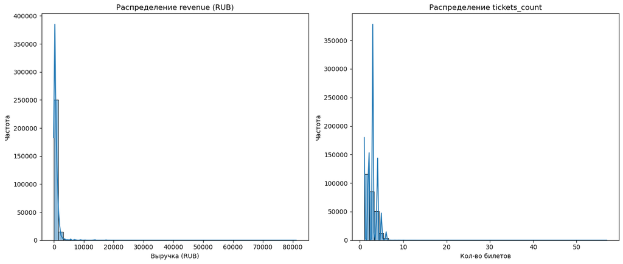

```python
# Визуализация распределения
fig, axes = plt.subplots(1, 2, figsize=(14, 6))

sns.histplot(merged_df["revenue"], bins=50, kde=True, ax=axes[0])
axes[0].set_title("Распределение revenue (RUB)")
axes[0].set_xlabel("Выручка (RUB)")
axes[0].set_ylabel("Частота")

sns.histplot(merged_df["tickets_count"], bins=50, kde=True, ax=axes[1])
axes[1].set_title("Распределение tickets_count")
axes[1].set_xlabel("Кол-во билетов")
axes[1].set_ylabel("Частота")

plt.tight_layout()
plt.show()
```

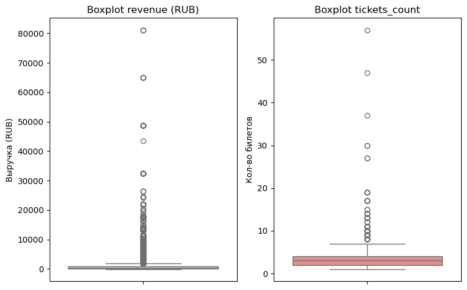

```python
# Визуализация распределения (boxplot)
fig, axes = plt.subplots(1, 2, figsize=(8, 5))

sns.boxplot(y=merged_df["revenue"], ax=axes[0], color="skyblue")
axes[0].set_title("Boxplot revenue (RUB)")
axes[0].set_ylabel("Выручка (RUB)")

sns.boxplot(y=merged_df["tickets_count"], ax=axes[1], color="lightcoral")
axes[1].set_title("Boxplot tickets_count")
axes[1].set_ylabel("Кол-во билетов")

plt.tight_layout()
plt.show()
```

Вывод: в данных о выручке присутствуют явные выбросы, которые влияют на статистику, средние значения малы по сравнению с экстремальными. Проведем фильтрацию по 99-му процентилю.

```python
#Определение 99-го процентиля
threshold = merged_df["revenue_rub"].quantile(0.99)
print(f"99-й процентиль для revenue_rub: {threshold:.2f} RUB")
```

```
99-й процентиль для revenue_rub: 2628.42 RUB
```

```python
# Фильтрация данных
filtered_df = merged_df[merged_df["revenue_rub"] <= threshold]

# Проверка размера данных
print(f"Исходный размер: {len(merged_df)} строк")
print(f"После очистки: {len(filtered_df)} строк")
print(f"Удалено {len(merged_df) - len(filtered_df)} строк.")
```

```
Исходный размер: 268659 строк
После очистки: 266032 строк
Удалено 2627 строк.
```

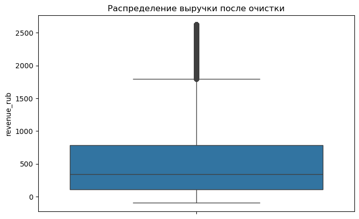

```python
# Визуализация распределения после фильтрации
plt.figure(figsize=(8, 5))
sns.boxplot(data=filtered_df, y="revenue_rub")
plt.title("Распределение выручки после очистки")
plt.show()
```

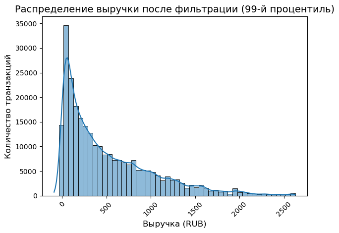

```python
# Построение гистограммы
ax = sns.histplot(
    data=filtered_df,
    x="revenue_rub",
    bins=50,
    kde=True
)

plt.title("Распределение выручки после фильтрации (99-й процентиль)", fontsize=14)
plt.xlabel("Выручка (RUB)", fontsize=12)
plt.ylabel("Количество транзакций", fontsize=12)

# Оптимизация отображения
plt.xticks(rotation=45)
plt.tight_layout()
plt.show()
```

Фильтрация по 99%-процентилю существенно улучшила распределение

### Вывод. После предобработки данных:

- Объединили все данные в один датафрейм.
- Выявили и удалили неявные дубликаты.
- Оптимизировали типы данных
- Провели статистический анализ данных в рублях и тенге.
- Нашли и обработали выбросы в revenue.
- Привели выручку к единой валюте - рублю
- Добавили новые столбцы с дополнительной информацией

## 3. Исследовательский анализ данных

### 3.1. Анализ распределения заказов по сегментам и их сезонные изменения

Для каждого месяца найдём количество заказов и визуализируем результаты. Проверим фиксируется ли увеличение заказов от июня к ноябрю 2024 года.

```python
# Группируем данные по месяцам и считаем количество заказов
monthly_orders = filtered_df.groupby('month')['order_id'].count()
monthly_orders
```

```
month
6     27748
7     36687
8     41130
9     65369
10    95098
Name: order_id, dtype: int64
```

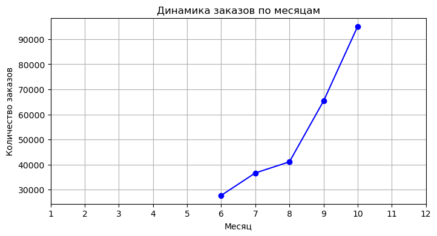

```python
# Визуализация динамики заказов по месяцам
plt.figure(figsize=(8, 4))
plt.plot(monthly_orders.index, monthly_orders.values, marker='o', linestyle='-', color='b')
plt.xlabel('Месяц')
plt.ylabel('Количество заказов')
plt.title('Динамика заказов по месяцам')
plt.xticks(range(1, 13))  # Отображаем все месяцы от 1 до 12
plt.grid(True)
plt.show()
```

График показывает явный рост количества заказов с июня по октябрь. Выводы:

- Июнь – Август: Умеренный рост количества заказов.
- Сентябрь – Октябрь: Резкий скачок популярности, особенно в октябре, где количество достигает максимума.

Возможные причины роста:

1. Начало театрального сезона (сентябрь-октябрь).
2. Осенние премьеры фильмов.
3. Рост интереса к культурным мероприятиям после летнего затишья.
4. Акции или скидки на билеты в осенний период.

Для осеннего и летнего периодов сравним распределение заказов билетов по разным категориям:

- тип мероприятия,
- тип устройства,
- категория мероприятия по возрастному рейтингу.

Результаты визуализируем.

```python
# Определяем летний и осенний периоды
summer_months = [6, 7, 8]
autumn_months = [9, 10]

# Фильтруем данные
summer_df = filtered_df[filtered_df['month'].isin(summer_months)]
autumn_df = filtered_df[filtered_df['month'].isin(autumn_months)]

# Функция для расчета доли заказов в сегменте
def calculate_share(df, column):
    return df[column].value_counts(normalize=True) * 100  # Доли в процентах
```

```python
#Анализ по типу мероприятия (event_type_main)
summer_event_type = calculate_share(summer_df, 'event_type_main')
autumn_event_type = calculate_share(autumn_df, 'event_type_main')
```

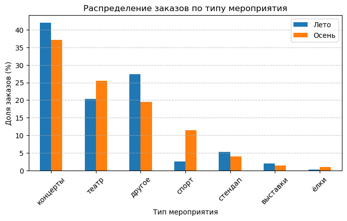

```python
# Визуализация
event_type_comparison = pd.DataFrame({'Лето': summer_event_type, 'Осень': autumn_event_type}).fillna(0)
event_type_comparison = event_type_comparison.sort_values(by='Осень', ascending=False)

event_type_comparison.plot(kind='bar', figsize=(8, 4), title='Распределение заказов по типу мероприятия')
plt.xlabel('Тип мероприятия')
plt.ylabel('Доля заказов (%)')
plt.xticks(rotation=45)
plt.grid(axis='y', linestyle='--', alpha=0.7)
plt.show()
```

```python
#Анализ по типу устройства (device_type_canonical)
summer_device = calculate_share(summer_df, 'device_type_canonical')
autumn_device = calculate_share(autumn_df, 'device_type_canonical')
```

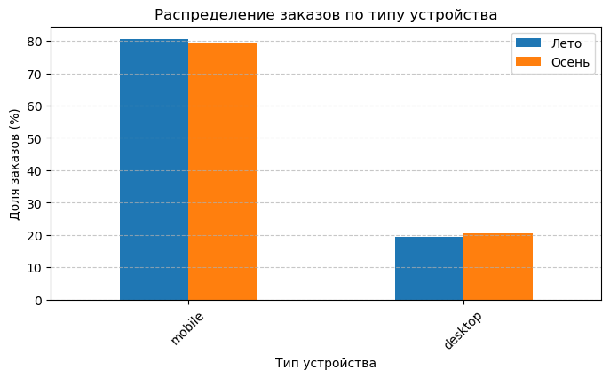

```python
# Визуализация
device_comparison = pd.DataFrame({'Лето': summer_device, 'Осень': autumn_device}).fillna(0)
device_comparison.plot(kind='bar', figsize=(8, 4), title='Распределение заказов по типу устройства')
plt.xlabel('Тип устройства')
plt.ylabel('Доля заказов (%)')
plt.xticks(rotation=45)
plt.grid(axis='y', linestyle='--', alpha=0.7)
plt.show()
```

```python
#Анализ по возрастному рейтингу (age_limit)
summer_age_limit = calculate_share(summer_df, 'age_limit')
autumn_age_limit = calculate_share(autumn_df, 'age_limit')
```

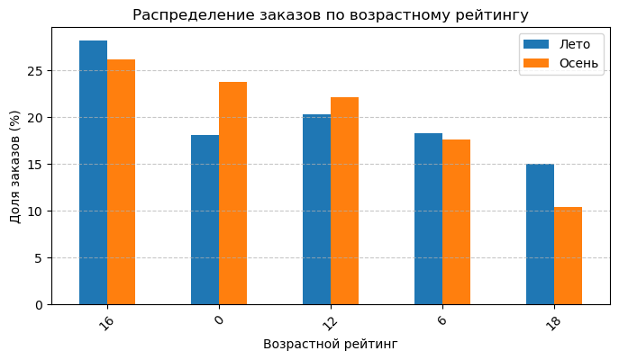

```python
# Визуализация
age_limit_comparison = pd.DataFrame({'Лето': summer_age_limit, 'Осень': autumn_age_limit}).fillna(0)
age_limit_comparison = age_limit_comparison.sort_values(by='Осень', ascending=False)

age_limit_comparison.plot(kind='bar', figsize=(8, 4), title='Распределение заказов по возрастному рейтингу')
plt.xlabel('Возрастной рейтинг')
plt.ylabel('Доля заказов (%)')
plt.xticks(rotation=45)
plt.grid(axis='y', linestyle='--', alpha=0.7)
plt.show()
```

Для удобства сравним все три категории

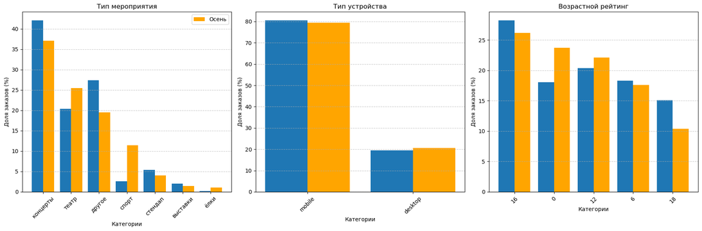

```python
# Выбираем категории для сравнения
categories = ['event_type_main', 'device_type_canonical', 'age_limit']
titles = ['Тип мероприятия', 'Тип устройства', 'Возрастной рейтинг']

# Создаем фигуру с тремя подграфиками
fig, axes = plt.subplots(1, 3, figsize=(18, 6))

for i, category in enumerate(categories):
    # Рассчитываем доли заказов для летнего и осеннего периодов
    summer_share = calculate_share(summer_df, category)
    autumn_share = calculate_share(autumn_df, category)

    # Объединяем данные
    comparison_df = pd.DataFrame({'Лето': summer_share, 'Осень': autumn_share}).fillna(0)
    comparison_df = comparison_df.sort_values(by='Осень', ascending=False)

    # Определяем ширину столбцов
    width = 0.4
    x = np.arange(len(comparison_df.index))

    # Строим группированные столбчатые диаграммы
    axes[i].bar(x - width/2, comparison_df['Лето'], width=width)
    axes[i].bar(x + width/2, comparison_df['Осень'], width=width, label='Осень', color='orange')

    # Настройки для оси X и Y
    axes[i].set_xlabel('Категории')
    axes[i].set_ylabel('Доля заказов (%)')
    axes[i].set_title(titles[i])
    axes[i].set_xticks(x)
    axes[i].set_xticklabels(comparison_df.index, rotation=45)
    axes[i].grid(axis='y', linestyle='--', alpha=0.7)

# Добавляем общую легенду
axes[0].legend()

plt.tight_layout()
plt.show()
```

Вывод по сравнению летнего и осеннего сезонов:

1. Тип мероприятия: лидер по бронированию - категория концерты, при этом, доля заказов летом выше, чем осенью. В категориях театр и спорт доля заказов осенью увеличилась, что может быть связано с началом культурного сезона. Летом же категория спорт – теряет интерес, как и категория театр. Интерес к выставкам и елкам остался низким, но ёлки могут вырасти ближе к декабрю.
2. Тип устройства: Мобильные устройства остаются лидерами по бронированию билетов в обоих сезонах (~80%). Десктоп показывает небольшое увеличение осенью, возможно, из-за планирования мероприятий на рабочем месте.
3. Возрастной рейтинг мероприятий: категория «0+» (детские мероприятия) осенью стала популярнее – возможно, из-за школьных каникул или семейных событий.Категории 16 и 18+ осенью существенно снизились.

Основные наблюдения:

- Наиболее популярные категории: театры, концерты и другое.
- Мобильные устройства остаются главным каналом бронирования.
- Осенью родители активнее выбирают мероприятия для детей, а категория 18+ снижается.

Изучим изменения выручки с продажи одного билета в зависимости от типа мероприятия летом и осенью. Выясним видна ли динамика средней стоимости билета в разрезе разных категорий мероприятий. Для каждого типа мероприятия рассчитаем среднее значение выручки с одного билета и найдем относительное изменение осенних значений по сравнению с летними. Результаты визуализируем

```python
# Отфильтруем данные по сезонам
summer_df = filtered_df[filtered_df['season'] == 'лето']
autumn_df = filtered_df[filtered_df['season'] == 'осень']
```

```python
# Рассчитаем среднюю выручку с одного билета по типу мероприятия
summer_avg_price = summer_df.groupby('event_type_main', observed=False)['one_ticket_revenue_rub'].mean()
autumn_avg_price = autumn_df.groupby('event_type_main', observed=False)['one_ticket_revenue_rub'].mean()

# Объединим результаты
price_comparison = pd.DataFrame({'Лето': summer_avg_price, 'Осень': autumn_avg_price})
```

Посчитаем на сколько процентов увеличилась или уменьшилась цена осенью по сравнению с летом. Найдём разницу между осенней и летней средней ценой и разделим разницу на летнюю среднюю цену

```python
# Рассчитаем относительное изменение цены
price_comparison['Изменение (%)'] = ((price_comparison['Осень'] - price_comparison['Лето']) /
                                     price_comparison['Лето']) * 100
price_comparison.sort_values(by='Изменение (%)', ascending=False, inplace=True)

# Выведем результат
price_comparison
```

| event_type_main | Лето | Осень | Изменение (%) |
| --- | --- | --- | --- |
| выставки | 86.310983 | 91.020658 | 5.456635 |
| стендап | 220.682070 | 230.780042 | 4.575801 |
| спорт | 49.817186 | 49.550235 | -0.535861 |
| другое | 76.657933 | 76.201661 | -0.595205 |
| концерты | 302.656183 | 269.214587 | -11.049368 |
| ёлки | 269.946538 | 229.129143 | -15.120548 |
| театр | 214.748878 | 176.157499 | -17.970468 |

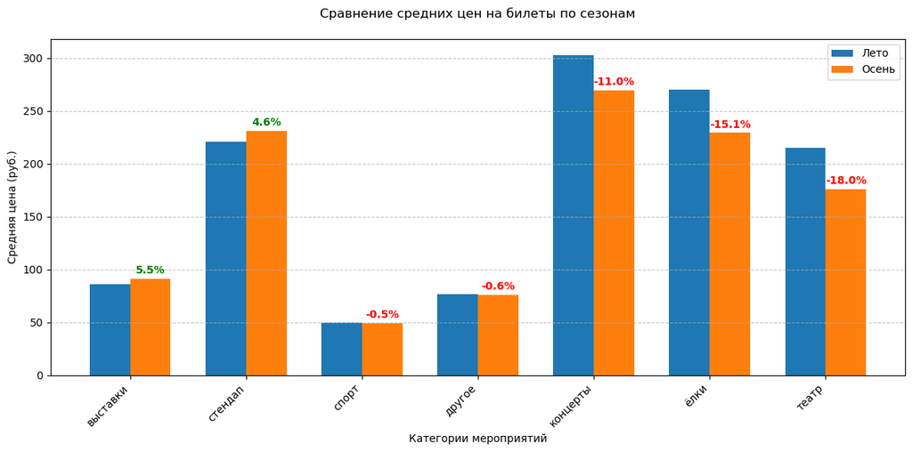

```python
# Создание фигуры
fig, ax = plt.subplots(figsize=(12, 6))

# Параметры для столбцов
categories = price_comparison.index
summer = price_comparison['Лето']
autumn = price_comparison['Осень']
changes = price_comparison['Изменение (%)']

# Позиции для группированных столбцов
x = np.arange(len(categories))
width = 0.35

# Построение столбцов
bars1 = ax.bar(x - width/2, summer, width, label='Лето', color='#1f77b4')
bars2 = ax.bar(x + width/2, autumn, width, label='Осень', color='#ff7f0e')

# Добавление аннотаций с процентным изменением (исправленная строка)
for i, change in enumerate(changes):
    color = 'green' if change > 0 else 'red'
    ax.text(
        x[i] + width/2,
        autumn.iloc[i] + 5,  # Используем .iloc для доступа по позиции
        f'{change:.1f}%',
        ha='center',
        color=color,
        weight='bold'
    )

# Настройка оформления
ax.set_title('Сравнение средних цен на билеты по сезонам', pad=20)
ax.set_xlabel('Категории мероприятий')
ax.set_ylabel('Средняя цена (руб.)')
ax.set_xticks(x)
ax.set_xticklabels(categories, rotation=45, ha='right')
ax.legend()
ax.grid(axis='y', linestyle='--', alpha=0.7)

# Автонастройка отступов
plt.tight_layout()
plt.show()
```

Осенью наблюдается перераспределение спроса между категориями мероприятий. Средняя стоимость билета значительно варьируется: в некоторых категориях цены растут из-за повышенного спроса, в других — снижаются из-за падения популярности или увеличения предложения.

Осенью рынок мероприятий адаптируется к сезонным предпочтениям, что отражается как в перераспределении спроса, так и в изменении ценовой политики.

### 3.2. Осенняя активность пользователей

Для анализа активности пользователей осенью 2024 года оставим только записи за сентябрь и октябрь 2024 года.

Проанализируем динамику изменений по дням для:

- общего числа заказов;
- количества активных пользователей DAU;
- среднего числа заказов на одного пользователя;
- средней стоимости одного билета.

Создадим сводную таблицу. Полученные результаты визуализируем с помощью линейного графика

```python
# Фильтрация данных за осень 2024 года (сентябрь и октябрь)
df_autumn = filtered_df[(filtered_df["data"].dt.year == 2024) & (filtered_df["data"].dt.month.isin([9, 10]))]
```

```python
# Создание сводной таблицы по дням
daily_metrics = df_autumn.groupby(df_autumn["data"].dt.date).agg(
    orders_count=("order_id", "count"),
    active_users=("user_id", "nunique"),
    total_tickets=("tickets_count", "sum"),
    total_revenue=("revenue_rub", "sum"),
)
# Округляем выручку до 2 знаков
daily_metrics["total_revenue"] = daily_metrics["total_revenue"].round(2)
```

```python
# Расчет дополнительных метрик
daily_metrics["orders_per_user"] = daily_metrics["orders_count"] / daily_metrics["active_users"]
daily_metrics["avg_ticket_price"] = daily_metrics["total_revenue"] / daily_metrics["total_tickets"]
daily_metrics.head()
```

| data | orders_count | active_users | total_tickets | total_revenue | orders_per_user | avg_ticket_price |
| --- | --- | --- | --- | --- | --- | --- |
| 2024-09-01 | 1230 | 489 | 3453 | 685632.08 | 2.515337 | 198.561274 |
| 2024-09-02 | 1276 | 491 | 3436 | 652113.81 | 2.598778 | 189.788653 |
| 2024-09-03 | 4943 | 656 | 14797 | 1092870.85 | 7.535061 | 73.857596 |
| 2024-09-04 | 1651 | 602 | 4460 | 801175.48 | 2.742525 | 179.635758 |
| 2024-09-05 | 1819 | 637 | 4869 | 931735.35 | 2.855573 | 191.360721 |

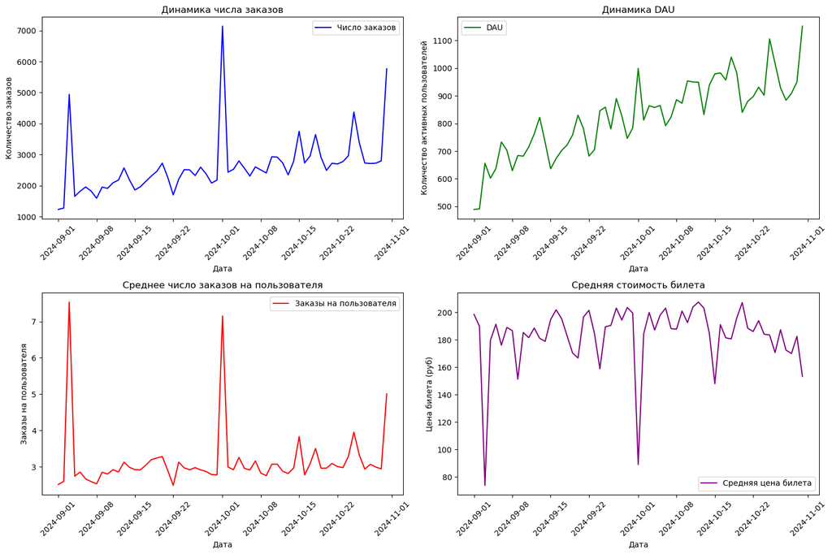

```python
# Визуализация
fig, axes = plt.subplots(2, 2, figsize=(15, 10))

# График общего числа заказов
axes[0, 0].plot(daily_metrics.index, daily_metrics["orders_count"], label="Число заказов", color='b')
axes[0, 0].set_title("Динамика числа заказов")
axes[0, 0].set_xlabel("Дата")
axes[0, 0].set_ylabel("Количество заказов")
axes[0, 0].tick_params(axis='x', rotation=45)
axes[0, 0].legend()

# График количества активных пользователей
axes[0, 1].plot(daily_metrics.index, daily_metrics["active_users"], label="DAU", color='g')
axes[0, 1].set_title("Динамика DAU")
axes[0, 1].set_xlabel("Дата")
axes[0, 1].set_ylabel("Количество активных пользователей")
axes[0, 1].tick_params(axis='x', rotation=45)
axes[0, 1].legend()

# График среднего числа заказов на пользователя
axes[1, 0].plot(daily_metrics.index, daily_metrics["orders_per_user"], label="Заказы на пользователя", color='r')
axes[1, 0].set_title("Среднее число заказов на пользователя")
axes[1, 0].set_xlabel("Дата")
axes[1, 0].set_ylabel("Заказы на пользователя")
axes[1, 0].tick_params(axis='x', rotation=45)
axes[1, 0].legend()

# График средней стоимости одного билета
axes[1, 1].plot(daily_metrics.index, daily_metrics["avg_ticket_price"], label="Средняя цена билета", color='purple')
axes[1, 1].set_title("Средняя стоимость билета")
axes[1, 1].set_xlabel("Дата")
axes[1, 1].set_ylabel("Цена билета (руб)")
axes[1, 1].tick_params(axis='x', rotation=45)
axes[1, 1].legend()

plt.tight_layout()
plt.show()
```

- Выраженные пики в начале сентября и октября могут быть связаны с крупными событиями(1 сентября), акциями или выходом популярных фильмов. После резких пиков происходит возврат к среднему уровню, но с постепенным ростом.
- Количество активных пользователей стабильно растёт в течение двух месяцев.
- Цена билета в целом стабильна, но есть несколько резких провалов, которые попадают на пики количества заказов. Видимо акции и снижение средней цены сформировало большой спрос в начале сентября и октября. В некоторые периоды (например, середина октября) наблюдается небольшое снижение средней стоимости билета.

Осенью наблюдается стабильный рост пользовательской активности. Есть отдельные дни с аномальным ростом числа заказов и DAU, возможно, связанные с маркетинговыми кампаниями. Средняя стоимость билета остаётся относительно стабильной, но бывают периоды резкого снижения.

Изучим недельную цикличность. Выделим день недели и сравним пользовательскую активность в понедельник и в воскресенье

```python
# Добавим колонку с днем недели
df_autumn = df_autumn.copy()
df_autumn.loc[:, "day_of_week"] = df_autumn["data"].dt.dayofweek
```

```python
# Группируем по дням недели и вычисляем метрики
weekday_stats = df_autumn.groupby('day_of_week').agg(
    orders=('order_id', 'nunique'),
    dau=('user_id', 'nunique'),
    avg_ticket_price=('one_ticket_revenue_rub', 'mean')).reset_index()

weekday_stats['orders_per_user'] = weekday_stats['orders'] / weekday_stats['dau']
weekday_stats
```

|  | day_of_week | orders | dau | avg_ticket_price | orders_per_user |
| --- | --- | --- | --- | --- | --- |
| 0 | 0 | 20393 | 3648 | 184.659819 | 5.590186 |
| 1 | 1 | 30329 | 3984 | 139.836845 | 7.612701 |
| 2 | 2 | 21694 | 3990 | 186.548140 | 5.437093 |
| 3 | 3 | 25916 | 4123 | 178.354836 | 6.285714 |
| 4 | 4 | 23581 | 3956 | 185.995714 | 5.960819 |
| 5 | 5 | 20226 | 3774 | 192.670031 | 5.359300 |
| 6 | 6 | 18328 | 3603 | 198.814202 | 5.086872 |

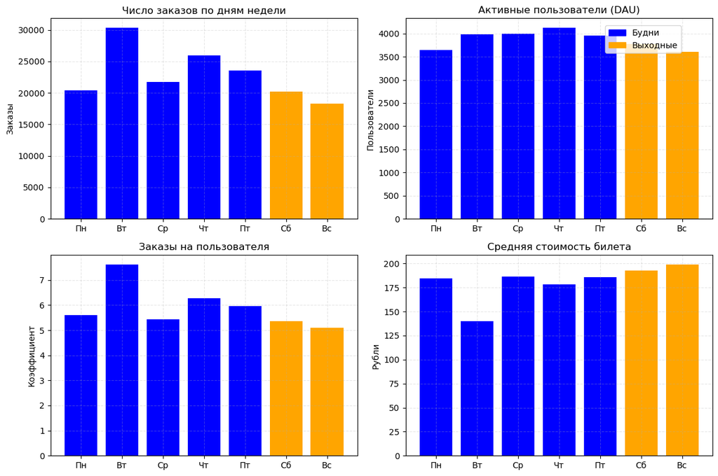

```python
# Создаем список цветов: выходные (5,6) - оранжевый, будни - синий
colors = ['blue' if day < 5 else 'orange' for day in weekday_stats['day_of_week']]

# Короткие названия дней недели на русском
day_labels = ['Пн', 'Вт', 'Ср', 'Чт', 'Пт', 'Сб', 'Вс']

# Настройка графиков
fig, axes = plt.subplots(2, 2, figsize=(12, 8))
plt.subplots_adjust(hspace=0.3, wspace=0.2)

# График 1: Общее число заказов
axes[0, 0].bar(day_labels, weekday_stats['orders'], color=colors)
axes[0, 0].set_title('Число заказов по дням недели', fontsize=12)
axes[0, 0].set_ylabel('Заказы')

# График 2: DAU (активные пользователи)
axes[0, 1].bar(day_labels, weekday_stats['dau'], color=colors)
axes[0, 1].set_title('Активные пользователи (DAU)', fontsize=12)
axes[0, 1].set_ylabel('Пользователи')

# График 3: Заказы на пользователя
axes[1, 0].bar(day_labels, weekday_stats['orders_per_user'], color=colors)
axes[1, 0].set_title('Заказы на пользователя', fontsize=12)
axes[1, 0].set_ylabel('Коэффициент')

# График 4: Средняя стоимость билета
axes[1, 1].bar(day_labels, weekday_stats['avg_ticket_price'], color=colors)
axes[1, 1].set_title('Средняя стоимость билета', fontsize=12)
axes[1, 1].set_ylabel('Рубли')

# Общие настройки
for ax in axes.flat:
    ax.grid(alpha=0.3, linestyle='--')
    ax.tick_params(axis='x')

# Легенда
legend_elements = [
    plt.Rectangle((0,0), 1, 1, color='blue', label='Будни'),
    plt.Rectangle((0,0), 1, 1, color='orange', label='Выходные')
]
fig.legend(handles=legend_elements, loc='upper right', bbox_to_anchor=(0.95, 0.95))

plt.tight_layout()
plt.show()
```

Заказы концентрируются в будние дни (особенно в середине недели), снижаясь к выходным. Это может быть связано с планированием мероприятий после работы/учебы.

Активность пользователей напрямую влияет на количество заказов.

Пик пользовательской активности и заказов, особенно в середине недели. В выходные видим снижение активности и рост средней стоимости билетов. Это может указывать на смещение спроса в сторону более дорогих мероприятий.

### 3.3. Популярные события и партнёры

Для каждого региона посчитаем уникальное количество мероприятий и общее число заказов.

```python
# Группируем данные по регионам и считаем метрики
region_stats = filtered_df.groupby('region_name', observed=False).agg(
    unique_events=('event_id', 'nunique'),
    total_orders=('order_id', 'count')).reset_index()
```

```python
# Рассчитываем доли
total_events = region_stats['unique_events'].sum()
total_orders_all = region_stats['total_orders'].sum()

region_stats['event_share'] = (region_stats['unique_events'] / total_events) * 100
region_stats['order_share'] = (region_stats['total_orders'] / total_orders_all) * 100

# Выделяем топ-5 регионов по  количеству мероприятий
top_region = region_stats.sort_values('unique_events', ascending=False).head(5)
```

Для каждого билетного партнёра посчитаем

- общее число уникальных мероприятий,
- обработанных заказов
- суммарную выручку с заказов билетов.

```python
# Группируем данные по партнерам и считаем основные метрики
partner_stats = filtered_df.groupby('service_name', observed=False).agg(
    unique_events=('event_id', 'nunique'),
    total_orders=('order_id', 'count'),
    total_revenue=('revenue_rub', lambda x: round(x.sum(), 2))
).reset_index()

# Рассчитываем доли от общего количества
total_events_all = partner_stats['unique_events'].sum()
total_orders_all = partner_stats['total_orders'].sum()
total_revenue_all = partner_stats['total_revenue'].sum()

partner_stats = partner_stats.assign(
    events_share=partner_stats['unique_events'] / total_events_all * 100,
    orders_share=partner_stats['total_orders'] / total_orders_all * 100,
    revenue_share=partner_stats['total_revenue'] / total_revenue_all * 100
)

# Настраиваем отображение чисел
pd.set_option('display.float_format', '{:.2f}'.format)

# Выделяем топ-5 партнеров по выручке
top_partners = partner_stats.sort_values('total_revenue', ascending=False).head(5)
top_partners
```

|  | service_name | unique_events | total_orders | total_revenue | events_share | orders_share | revenue_share |
| --- | --- | --- | --- | --- | --- | --- | --- |
| 3 | Билеты без проблем | 4122 | 57862 | 22567584.24 | 17.46 | 21.75 | 16.46 |
| 24 | Мой билет | 1273 | 31190 | 19154025.49 | 5.39 | 11.72 | 13.97 |
| 25 | Облачко | 2246 | 24226 | 17062981.45 | 9.51 | 9.11 | 12.45 |
| 21 | Лови билет! | 4730 | 37984 | 15620130.59 | 20.04 | 14.28 | 11.39 |
| 8 | Весь в билетах | 822 | 15146 | 15254476.26 | 3.48 | 5.69 | 11.13 |

```python
top_region
```

|  | region_name | unique_events | total_orders | event_share | order_share |
| --- | --- | --- | --- | --- | --- |
| 23 | Каменевский регион | 5716 | 82654 | 26.40 | 31.07 |
| 60 | Североярская область | 3674 | 39955 | 16.97 | 15.02 |
| 77 | Широковская область | 1205 | 14944 | 5.57 | 5.62 |
| 57 | Светополянский округ | 1041 | 7041 | 4.81 | 2.65 |
| 52 | Речиновская область | 678 | 5827 | 3.13 | 2.19 |

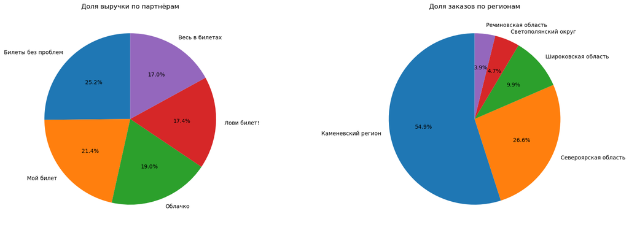

```python
#Визуализация

fig, axes = plt.subplots(1, 2, figsize=(18, 6))

# Доли партнёров
axes[0].pie(
    top_partners['revenue_share'],
    labels=top_partners['service_name'],
    autopct='%1.1f%%',
    startangle=90,
    colors=sns.color_palette("tab10")
)
axes[0].set_title('Доля выручки по партнёрам')

# Доли регионов
axes[1].pie(
    top_region['order_share'],
    labels=top_region['region_name'],
    autopct='%1.1f%%',
    startangle=90,
    colors=sns.color_palette("tab10")
)
axes[1].set_title('Доля заказов по регионам')

plt.tight_layout()
plt.show()
```

Сервис сильно зависит от 2-3 регионов, что повышает риски (например, при спаде спроса в Каменевском регионе).

### 4. Статистический анализ данных

Проверим две гипотезы, которые предполагают большую активность пользователей мобильных устройств:

1. Среднее количество заказов на одного пользователя мобильного приложения выше по сравнению с пользователями стационарных устройств.
2. Среднее время между заказами пользователей мобильных приложений выше по сравнению с пользователями стационарных устройств.

Будем использовать данные только за осенний период. Сперва, изучим сравниваемые данные, обоснуем выбор статистического теста, укажем формулировку нулевой и альтернативной гипотез.

Так как нам необходимо знать время между заказами пользователей отфильтруем данные и разделим по типам утройств

```python
#  Фильтрация данных
# # df_filtered = df_autumn.dropna(subset=["days_since_prev"])
```

```python
# Разделение на мобильные и стационарные устройства
mobile_df = df_autumn[df_autumn["device_type_canonical"] == "mobile"]
desktop_df = df_autumn[df_autumn["device_type_canonical"] == "desktop"]
```

```python
def prepare_user_stats(df):
    # Группировка по пользователям
    user_stats = df.groupby("user_id").agg(
        avg_orders_per_user=("order_id", "count"),   # Количество заказов
        avg_days_between_orders=("days_since_prev", "mean")  # Среднее время между заказами
    ).reset_index()

    return user_stats

# Применяем к мобильным и стационарным устройствам
mobile_user_stats = prepare_user_stats(mobile_df)
desktop_user_stats = prepare_user_stats(desktop_df)

print("Статистика по среднему количеству заказов на пользователя (мобильные устройства):")
print(mobile_user_stats["avg_orders_per_user"].describe())

print("\nСтатистика по среднему времени между заказами (мобильные устройства):")
print(mobile_user_stats["avg_days_between_orders"].describe())

print("\nСтатистика по среднему количеству заказов на пользователя (стационарные устройства):")
print(desktop_user_stats["avg_orders_per_user"].describe())

print("\nСтатистика по среднему времени между заказами (стационарные устройства):")
print(desktop_user_stats["avg_days_between_orders"].describe())
```

```
Статистика по среднему количеству заказов на пользователя (мобильные устройства):
count   10198.00
mean       12.50
std        80.14
min         1.00
25%         1.00
50%         3.00
75%         6.00
max      4335.00
Name: avg_orders_per_user, dtype: float64

Статистика по среднему времени между заказами (мобильные устройства):
count   10198.00
mean       20.63
std        27.37
min         0.00
25%         2.05
50%         9.50
75%        28.00
max       148.00
Name: avg_days_between_orders, dtype: float64

Статистика по среднему количеству заказов на пользователя (стационарные устройства):
count   4035.00
mean       8.18
std       39.49
min        1.00
25%        1.00
50%        2.00
75%        5.00
max     1504.00
Name: avg_orders_per_user, dtype: float64

Статистика по среднему времени между заказами (стационарные устройства):
count   4035.00
mean      14.88
std       24.22
min        0.00
25%        1.00
50%        4.50
75%       17.00
max      146.00
Name: avg_days_between_orders, dtype: float64
```

Данные явно имеют выбросы и не распределены нормально (по результатам describe() значения max значительно превышают 75-й перцентиль). Из-за большого размера выборок и асимметрии данных используем U-тест Манна-Уитни

### Гипотеза 1: Среднее количество заказов на одного пользователя мобильного приложения выше, чем у пользователей стационарных устройств

H0 (нулевая гипотеза): Среднее количество заказов на одного пользователя мобильного приложения меньше или равно среднему количеству заказов пользователей стационарных устройств.

H1 (альтернативная гипотеза): Среднее количество заказов на одного пользователя мобильного приложения больше среднего количества заказов пользователей стационарных устройств.

### Гипотеза 2: Среднее время между заказами пользователей мобильных приложений выше, чем у пользователей стационарных устройств

H0 (нулевая гипотеза): Среднее время между заказами пользователей мобильного приложения меньше или равно среднему времени между заказами пользователей стационарных устройств.

H1 (альтернативная гипотеза): Среднее время между заказами пользователей мобильного приложения больше среднего времени между заказами пользователей стационарных устройств.

```python
def perform_hypothesis_test(sample1, sample2, alternative='greater'):
    results = {}

    # Выполняем U-тест Манна-Уитни
    u_stat, p_value = stats.mannwhitneyu(
        sample1,
        sample2,
        alternative=alternative,
        method='auto'
    )

    results['mannwhitney'] = {
        'statistic': u_stat,
        'pvalue': p_value,
        'alternative': alternative
    }

    return results
```

```python
# Выделяем нужные данные
desktop_orders = desktop_user_stats['avg_orders_per_user']
mobile_orders = mobile_user_stats['avg_orders_per_user']

desktop_days = desktop_user_stats['avg_days_between_orders']
mobile_days = mobile_user_stats['avg_days_between_orders']

# Проверка гипотезы 1: Количество заказов (мобильные > десктоп)
print("Гипотеза 1: Распределение количества заказов (мобильные > десктоп)")
results_orders = perform_hypothesis_test(mobile_orders, desktop_orders, alternative='greater')

for test_name, test_result in results_orders.items():
    print(f"{'MEDIAN (Mobile)':<20}: {mobile_orders.median():.2f}")
    print(f"{'MEDIAN (Desktop)':<20}: {desktop_orders.median():.2f}")
    print(f"{test_name.upper():<15} | Stat: {test_result['statistic']:.2f} | p-value: {test_result['pvalue']:.5f}")
    print(f"Вывод: {'Отвергаем H₀' if test_result['pvalue'] < 0.05 else 'Нет оснований отвергать H₀'}")
    print(f"Интерпретация: {'Мобильные пользователи имеют статистически значимо больше заказов' if test_result['pvalue'] < 0.05 else 'Нет значимых различий'}")
    print()

# Проверка гипотезы 2: Время между заказами (мобильные > десктоп)
print("\nГипотеза 2: Распределение времени между заказами (мобильные > десктоп)")
results_days = perform_hypothesis_test(mobile_days, desktop_days, alternative='greater')

for test_name, test_result in results_days.items():
    print(f"{'MEDIAN (Mobile)':<20}: {mobile_days.median():.2f}")
    print(f"{'MEDIAN (Desktop)':<20}: {desktop_days.median():.2f}")
    print(f"{test_name.upper():<15} | Stat: {test_result['statistic']:.2f} | p-value: {test_result['pvalue']:.5f}")
    print(f"Вывод: {'Отвергаем H₀' if test_result['pvalue'] < 0.05 else 'Нет оснований отвергать H₀'}")
    print(f"Интерпретация: {'Мобильные пользователи имеют статистически значимо большее время между заказами' if test_result['pvalue'] < 0.05 else 'Нет значимых различий'}")
    print()
```

```
Гипотеза 1: Распределение количества заказов (мобильные > десктоп)
MEDIAN (Mobile)     : 3.00
MEDIAN (Desktop)    : 2.00
MANNWHITNEY     | Stat: 22853576.50 | p-value: 0.00000
Вывод: Отвергаем H₀
Интерпретация: Мобильные пользователи имеют статистически значимо больше заказов


Гипотеза 2: Распределение времени между заказами (мобильные > десктоп)
MEDIAN (Mobile)     : 9.50
MEDIAN (Desktop)    : 4.50
MANNWHITNEY     | Stat: 23922929.50 | p-value: 0.00000
Вывод: Отвергаем H₀
Интерпретация: Мобильные пользователи имеют статистически значимо большее время между заказами
```

U-тест Манна-Уитни показал статистически значимые различия (p-value < 0.05).

Пользователи мобильных устройств совершают больше заказов в среднем, чем пользователи стационарных устройств. Это подтверждает гипотезу о большей активности мобильных пользователей. Время между заказами у мобильных пользователей действительно больше

### 5. Общий вывод и рекомендации

Общий вывод и рекомендации

1. Информация о данных:

Период анализа: Осень 2024 (сентябрь-октябрь). Данные: Активность пользователей (заказы, средний чек, тип устройств), категории мероприятий, возрастной рейтинг, регионы, партнеры.

2. Основные результаты анализа:

2.1. Востребованность мероприятий:

- Лидеры: Концерты (лидер по заказам), театр и спорт (рост осенью).
- Сезонные изменения: Осенью растет спрос на театр (+), спорт (+), детские мероприятия (0+).
- Снижение интереса к концертам (-), категориям 16+ и 18+.

2.3. Активность пользователей:

- Пики заказов: Вторник, четверг, пятница (планирование на буднях).
- Минимумы: Выходные (но выше средний чек — возможно, премиальные события).
- Устройства: Мобильные — 80% заказов, осенью небольшой рост десктопов.

Гипотеза 1: Пользователи мобильных устройств совершают больше заказов (p-value < 0.05). Подтверждена. Гипотеза 2: Время между заказами у мобильных пользователей больше (p-value < 0.05).

4. Рекомендации:
- Усилить мобильный канал: Оптимизировать приложение под импульсные покупки (упростить навигацию, добавить push-уведомления).
- Внедрить систему рекомендаций на основе возраста (акцент на 0+ и семейные мероприятия).
- Региональные риски: Диверсифицировать мероприятия в менее зависимых регионах (например, запустить локальные проекты в Североярской области).
- Партнеры: Сотрудничать с «Весь в билетах» и «Мой билет» для монетизации нишевых событий.
- Анализировать причины низкой эффективности «Лови билет!» (возможно, пересмотреть ценовую политику).

Осенью сервис демонстрирует рост за счет семейной аудитории и культурных мероприятий. Мобильные пользователи — ключевая аудитория, но их поведение требует более глубокого анализа. Рекомендуется сфокусироваться на оптимизации мобильного опыта, ценовой стратегии для театра/ёлкок и диверсификации регионов.